# 📋 ANÁLISE DE SENTIMENTO DE UMA REPORTAGEM SOBRE A NICARÁGUA

## 1. Introdução

A análise de sentimentos é uma técnica de Processamento de Linguagem Natural (Natural Language Processing - NLP) utilizada para identificar automaticamente a polaridade emocional presente em um texto.

Embora seja amplamente aplicada em avaliações de produtos e redes sociais, essa técnica também pode ser utilizada para analisar reportagens jornalísticas, permitindo identificar o tom predominante da cobertura, o vocabulário utilizado e os principais aspectos emocionais associados ao conteúdo.

Neste estudo será analisada uma reportagem publicada pela BBC News Brasil sobre as declarações do presidente da Nicarágua, Daniel Ortega, relacionadas ao processo eleitoral do país.

A reportagem aborda temas como:

- democracia;
- autoritarismo;
- repressão política;
- eleições;
- direitos humanos;
- comunidade internacional.

Além da classificação de sentimento (positivo, negativo ou neutro), serão realizadas análises complementares como:

- frequência de palavras;
- nuvem de palavras;
- palavras mais relevantes;
- emoções predominantes;
- direitos humanos;
- interpretação dos resultados.

O objetivo é demonstrar um fluxo profissional de análise textual utilizando Python.

## 🎯 Objetivos

Este projeto busca responder às seguintes questões:

- Qual é o sentimento predominante da reportagem?
- O texto possui maior carga negativa ou positiva?
- Quais palavras aparecem com maior frequência?
- Quais emoções são mais associadas ao texto?
- Quais temas recebem maior destaque?
- interpretação dos resultados.

## 📚 Instalação de bibliotecas

```python
# ==========================================================
# Instação das bibliotecas
# ==========================================================
!pip install nltk > /dev/null 2>&1
!pip install wordcloud > /dev/null 2>&1
!pip install textblob > /dev/null 2>&1
!pip install transformers > /dev/null 2>&1
!pip install torch > /dev/null 2>&1
!pip install -q spacy > /dev/null 2>&1
!python -m spacy download pt_core_news_sm > /dev/null 2>&1
!pip install -q pysentimiento > /dev/null 2>&1
```

## 📚 Importes de bibliotecas

```python
# ==========================================================
# Importes
# ==========================================================
# O módulo sys em Python é uma biblioteca embutida que serve para
#interagir diretamente com o interpretador e o ambiente de execução.
import sys
# ==========================================================
# Módulo nativo para trabalhar com expressões regulares (Regex),
# permitindo buscar, validar e manipular padrões de textos em strings.
import re
# ==========================================================
# O NLTK (Natural Language Toolkit) é a principal biblioteca em Python
# para processamento de linguagem natural (PLN), permitindo tokenização,
# lematização e análise de sentimentos.
import nltk
# ==========================================================
# O Pandas é a principal biblioteca do Python para manipulação,
# limpeza e análise de dados tabulares, oferecendo estruturas como
# Series e DataFrame.
import pandas as pd
# ==========================================================
# A instrução from collections import Counter serve para importar a
# classe Counter do módulo nativo collections do Python, que é utilizada
# para contar automaticamente a frequência de elementos em um objeto
# iterável (como listas, strings ou tuplas).
from collections import Counter
# ==========================================================
# A linha de código from wordcloud import WordCloud serve para importar
# a classe WordCloud da biblioteca externa chamada wordcloud no Python,
# a qual é utilizada para criar nuvens de palavras (representações
# visuais de frequências de termos em um texto).
from wordcloud import WordCloud
# ==========================================================
# A linha de código import matplotlib.pyplot as plt serve para importar
# o módulo pyplot da biblioteca Matplotlib no Python, que é a principal
# ferramenta para a criação e customização de gráficos bidimensionais.
import matplotlib.pyplot as plt
# ==========================================================
# O comando from nltk.corpus import stopwords serve para importar a lista
# de palavras vazias (stop words) da biblioteca NLTK (Natural Language Toolkit)
# no Python. Essas palavras (como "de", "a", "o", "com") são removidas durante
# o pré-processamento de texto porque não agregam significado semântico para a análise.
from nltk.corpus import stopwords
# ==========================================================
# A linha de código from textblob import TextBlob é usada para importar a classe
# principal da TextBlob, uma biblioteca Python focada no Processamento de
# Linguagem Natural (NLP). Ela simplifica a análise e manipulação de dados
# textuais ao fornecer uma interface amigável sobre outras ferramentas mais complexas, como o NLTK
from textblob import TextBlob
# ==========================================================
# Essa função é a forma mais simples e rápida de utilizar modelos de Inteligência Artificial
# pré-treinados para tarefas de Processamento de Linguagem Natural (NLP), áudio e visão
# computacional. Ela abstrai toda a complexidade de pré-processamento de texto, tokenização
# e inferência em poucas linhas de código.
from transformers import pipeline
```

## 📚 Importes de funções auxiliares

```python
# ==========================================================
# Funções auxiliares
# ==========================================================
sys.path.append("/kaggle/input/datasets/jcarlossc/dataset-helpers-analysis-news-report")
# função de leitura do arquivo txt
from function_new_report import read_txt
# Função estatística
from function_new_report import text_statistics
# Pré-processamento
from function_new_report import preprocess_text
# Gráfico de nuvens de palavras
from function_new_report import plot_wordcloud
# Gráfico de barras
from function_new_report import plot_sentiment_probability
```

## 🔎 Leitura da reportagem

```python
# ==========================================================
# Arquivo da reportagem
# ==========================================================
path = "/kaggle/input/datasets/jcarlossc/reportagem-bbc-brasil/reportagem_bbc_brasil.txt"
```

```python
# ==========================================================
# Leitura do arquivo da reportagem - TXT
# ==========================================================
text = read_txt(path)
```

## 🧮 Estatísticas do texto

```python
# ==========================================================
# Função Estatística
# ==========================================================
text_statistics(text)
```

```
{'Quantidade de letras': 14729,
 'Letras sem espaços': 12441,
 'Sentenças': 104,
 'Quantidade de palavras': 2293,
 'Palavras únicas': 893,
 'Diversidade lexical': 0.389,
 'Comprimento médio das palavras': 5.25,
 'Comprimento mediano das palavras': np.float64(5.0),
 'Comprimento máximo de palavra': 18,
 'Comprimento médio das sentenças': 22.05,
 'Comprimento máximo da sentença': 89,
 'Números': 78,
 'Letras maiúsculas': 472,
 'Pontuação': 383,
 'Palavras mais usadas': [('de', 106),
  ('a', 90),
  ('o', 66),
  ('e', 60),
  ('que', 52),
  ('ortega', 51),
  ('em', 45),
  ('da', 42),
  ('do', 37),
  ('no', 28),
  ('com', 21),
  ('para', 20),
  ('dos', 20),
  ('poder', 18),
  ('foi', 18),
  ('mais', 17),
  ('nicarágua', 16),
  ('os', 16),
  ('eleições', 15),
  ('na', 15)]}
```

### 💡 Análise das estatísticas

A análise estatística evidencia que a reportagem apresenta uma estrutura textual consistente e adequada para aplicações de Processamento de Linguagem Natural. O texto combina uma diversidade lexical moderada com elevada concentração de termos relacionados ao contexto político, refletindo um foco temático bem delimitado. A repetição de entidades como "Ortega", "Nicarágua", "poder" e "eleições" reforça a centralidade desses elementos na narrativa. Além disso, o tamanho do documento, a extensão média das sentenças e a presença de informações numéricas indicam um texto informativo, rico em contexto, tornando-o apropriado para etapas posteriores como remoção de stopwords, análise de frequência, extração de palavras-chave, modelagem de tópicos, reconhecimento de entidades nomeadas e análise de sentimentos.

## ⚙️ Pré-processamento

```python
# ==========================================================
# Função de pré-processamento do texto
# ==========================================================
text_preprocess = preprocess_text(text)
```

## 📌 Frequência de Palavras

```python
# ==========================================================
# Frequência
# ==========================================================
# Cria um contador usando a ferramenta Counter.
frequency = Counter(text_preprocess)
# Usa a função que retorna uma lista com os 30 elementos que mais apareceram.
frequency.most_common(30)
```

```
[('ortega', 52),
 ('poder', 18),
 ('nicarágua', 16),
 ('eleições', 15),
 ('governo', 14),
 ('anos', 13),
 ('sandinista', 11),
 ('discurso', 10),
 ('presidente', 9),
 ('afirmou', 8),
 ('estado', 8),
 ('nacional', 8),
 ('oposição', 7),
 ('país', 7),
 ('após', 7),
 ('presidência', 7),
 ('reformas', 7),
 ('estados', 6),
 ('disse', 6),
 ('tempo', 6),
 ('somoza', 6),
 ('dois', 6),
 ('eleição', 6),
 ('candidatos', 6),
 ('internacional', 6),
 ('direitos', 6),
 ('daniel', 5),
 ('unidos', 5),
 ('rubio', 5),
 ('comunidade', 5)]
```

### 💡 Principais evidências temáticas

- Personagem central: Ortega (52 ocorrências).
- Tema predominante: poder, governo, presidência e eleições.
- Contexto geográfico: Nicarágua como foco principal da narrativa.
- Aspectos institucionais: oposição, reformas, Estado e direitos.
- Contexto histórico: referências ao sandinismo e à família Somoza.
- Dimensão internacional: menções aos Estados Unidos, à comunidade internacional e a atores políticos estrangeiros.

Em conjunto, essas frequências indicam que a reportagem possui alta concentração temática, característica comum de textos jornalísticos especializados, nos quais a repetição de entidades nomeadas e conceitos centrais contribui para manter a coerência discursiva e reforçar os principais assuntos abordados.

## 📉 Nuvens de Palavras

[figure not shown]

```python
# ==========================================================
# Função de gráfico
# ==========================================================
plot_wordcloud(text_preprocess)
```

## 📑 Análise de Sentimentos

```python
# ==========================================================
# Autenticação no Hugging Face
# ==========================================================
# Recupera o token armazenado nos Secrets do Kaggle.
# O token permite autenticação no Hugging Face Hub,
# aumentando o limite de requisições e acelerando
# o download de modelos.
import os
from kaggle_secrets import UserSecretsClient

user_secrets = UserSecretsClient()
os.environ["HF_TOKEN"] = user_secrets.get_secret("HF_TOKEN")

# ==========================================================
# Configuração de avisos do PyTorch
# ==========================================================
# Oculta o aviso referente ao parâmetro 'pin_memory',
# exibido quando o notebook é executado sem GPU.
# Esse aviso não interfere na execução da análise.
import warnings
warnings.filterwarnings(
    "ignore",
    message=".*pin_memory.*"
)

# ==========================================================
# Criação do analisador de sentimentos
# ==========================================================
# Carrega o modelo pré-treinado do pysentimiento
# para análise de sentimentos em português.
from pysentimiento import create_analyzer

analyzer = create_analyzer(task="sentiment", lang="pt")

# ==========================================================
# Predição do sentimento
# ==========================================================
# Executa a classificação do texto pré-processado,
# retornando o rótulo previsto e as probabilidades
# associadas a cada classe.
result = analyzer.predict(text_preprocess)
```

```python
# (resultado[0]) Primeiro item da lista de respostas.
# (output) Exibe a resposta ou texto gerado.
print(f"Sentimento predominante: {result[0].output}")

# (resultado[0]) Primeiro item da lista de respostas.
# (probas) exibe os números de certeza ou probabilidade de cada opção.
print(result[0].probas)
```

```
Sentimento predominante: NEU
{'NEG': 0.022049162536859512, 'NEU': 0.8834540247917175, 'POS': 0.09449686110019684}
```

```python
# ==========================================================
# Converte resultados para DataFrame
# ==========================================================
neg = result[0].probas["NEG"] * 100
neu = result[0].probas["NEU"] * 100
pos = result[0].probas["POS"] * 100

table = {
    "Sentimento": ["Negativo", "Neutro", "Positivo"],
    "Probabilidade": [
        neg,
        neu,
        pos
    ]
}
table = pd.DataFrame(table)
table
```

|  | Sentimento | Probabilidade |
| --- | --- | --- |
| 0 | Negativo | 2.204916 |
| 1 | Neutro | 88.345402 |
| 2 | Positivo | 9.449686 |

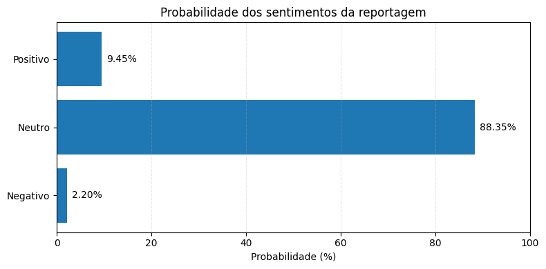

```python
plot_sentiment_probability(table)
```

### 💡 Análise de Sentimentos

A reportagem foi classificada como predominantemente neutra (NEU), com probabilidade de 88,35%, indicando que o modelo identificou uma linguagem majoritariamente informativa e objetiva. As probabilidades de sentimento positivo (9,45%) e negativo (2,20%) foram significativamente menores, sugerindo baixa presença de expressões emocionalmente carregadas.

Embora o texto trate de temas politicamente sensíveis, como eleições, governo, oposição e direitos humanos, o resultado evidencia que a narrativa é construída de forma predominantemente descritiva, característica comum de reportagens jornalísticas. Nesse contexto, a classificação neutra não significa ausência de acontecimentos negativos, mas sim que o texto apresenta os fatos com baixa carga emocional explícita.

## 📑 Análise de Emoções

```python
emotion = pipeline(
    "text-classification",
    model="j-hartmann/emotion-english-distilroberta-base",
    top_k=None
)

result = emotion(text_preprocess)
```

```python
df = (
    pd.DataFrame(result[0])
      .sort_values("score", ascending=False)
)
df["score"] = (df["score"]*100).round(2)
df.columns = ["Emoção", "Probabilidade (%)"]
df
```

|  | Emoção | Probabilidade (%) |
| --- | --- | --- |
| 0 | neutral | 62.27 |
| 1 | fear | 10.05 |
| 2 | joy | 7.52 |
| 3 | anger | 7.11 |
| 4 | surprise | 5.55 |
| 5 | sadness | 5.54 |
| 6 | disgust | 1.96 |

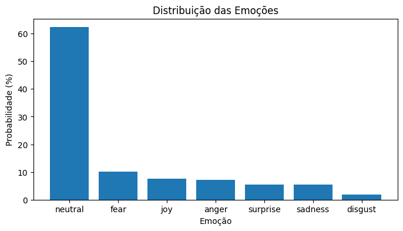

```python
import matplotlib.pyplot as plt

df_plot = (
    pd.DataFrame(result[0])
      .sort_values("score", ascending=False)
)

plt.figure(figsize=(8,4))
plt.bar(df_plot["label"], df_plot["score"]*100)

plt.ylabel("Probabilidade (%)")
plt.xlabel("Emoção")
plt.title("Distribuição das Emoções")

plt.show()
```

### Interpretação da Análise de Emoções

A análise de emoções identificou que o texto apresenta predominância da emoção **Neutro (62,27%)**, indicando que seu conteúdo é majoritariamente informativo e descritivo, característica comum em textos jornalísticos.

A segunda emoção mais representativa foi **Medo (10,05%)**, sugerindo que o texto aborda acontecimentos relacionados a conflitos, riscos, incertezas ou situações de tensão. Em menor proporção, foram identificadas emoções como **Alegria (7,52%)**, **Raiva (7,11%)**, **Surpresa (5,55%)**, **Tristeza (5,54%)** e **Desgosto (1,96%)**.

A coexistência dessas emoções demonstra que, embora a narrativa mantenha um tom predominantemente neutro, ela descreve eventos capazes de provocar diferentes respostas emocionais no leitor. A presença de medo, raiva e tristeza pode estar associada à descrição de crises, conflitos ou impactos sociais, enquanto a surpresa e a alegria podem refletir acontecimentos inesperados ou aspectos positivos mencionados ao longo do texto.

De forma geral, a distribuição emocional indica um texto de caráter informativo, enriquecido por elementos narrativos que despertam emoções secundárias, oferecendo uma visão mais abrangente sobre o impacto emocional do conteúdo analisado.

## 📑 Análise de Entidades

```python
import spacy

nlp = spacy.load("pt_core_news_sm")

doc = nlp(text)

import pandas as pd

data = [
    {
        "Entidade": ent.text,
        "Categoria": ent.label_
    }
    for ent in doc.ents
]

df = pd.DataFrame(data)

df.value_counts()
```

```
Entidade                  Categoria
Ortega                    PER          38
Nicarágua                 LOC          13
Estados Unidos            LOC           5
Daniel Ortega             PER           5
Ortega                    LOC           4
                                       ..
X                         MISC          1
comunidade internacional  ORG           1
instituto CID-Gallup      ORG           1
revolução sandinista      MISC          1
Àquela                    PER           1
Name: count, Length: 107, dtype: int64
```

### Interpretação da Análise de Entidades

A análise de entidades nomeadas identificou 107 combinações distintas entre entidades e categorias no conjunto de textos analisado. Entre as entidades mais frequentes, destaca-se **“Ortega”**, classificada como pessoa (`PER`) em 38 ocorrências, seguida por **“Nicarágua”**, classificada como local (`LOC`) em 13 ocorrências. Também aparecem **“Estados Unidos”**, com 5 ocorrências como local, e **“Daniel Ortega”**, identificado como pessoa em 5 ocorrências.

A predominância de entidades do tipo `PER` e `LOC` indica que os textos apresentam forte concentração em **personagens políticos e referências geográficas**. A frequência de “Ortega” e “Daniel Ortega” sugere que o político é uma das principais figuras mencionadas no corpus, enquanto a presença recorrente de “Nicarágua” reforça a centralidade do país no conteúdo analisado.

Entre as organizações (`ORG`), aparecem entidades como **“instituto CID-Gallup”** e **“comunidade internacional”**, embora com frequência significativamente menor. Já entidades classificadas como `MISC`, como **“revolução sandinista”**, representam conceitos ou acontecimentos que não se enquadram diretamente nas categorias de pessoa, local ou organização.

Também foram observadas possíveis inconsistências na classificação. Por exemplo, **“Ortega” aparece tanto como ****`PER`**** quanto como ****`LOC`**, indicando que algumas ocorrências podem ter sido classificadas incorretamente pelo modelo de NER. Dessa forma, os resultados devem ser interpretados considerando que modelos de reconhecimento de entidades podem apresentar erros dependendo do contexto linguístico.

De modo geral, a análise demonstra que o corpus está fortemente relacionado a **pessoas, locais e acontecimentos associados à Nicarágua**, permitindo identificar rapidamente os principais elementos mencionados nos textos e servindo como base para análises posteriores de frequência, relacionamento entre entidades e evolução dos temas ao longo do tempo.

## 📑 Conclusão

A análise de sentimentos classificou a reportagem como predominantemente neutra (88,35%), indicando que o texto apresenta um estilo informativo e objetivo. Embora aborde temas sensíveis relacionados à política, eleições e direitos humanos, a linguagem empregada mantém um caráter predominantemente descritivo, sem forte carga emocional. As probabilidades de sentimento positivo (9,45%) e negativo (2,20%) são significativamente menores, sugerindo que o modelo identificou poucas expressões explicitamente valorativas ou emocionalmente intensas.

Portanto, 88% de neutralidade para uma reportagem jornalística é um resultado coerente e não indica que a análise esteja errada. Pelo contrário, sugere que o modelo reconheceu o caráter predominantemente informativo do texto, em vez de interpretá-lo como uma opinião emocional.

## ✅ Discussão dos resultados

Limitação da análise: modelos de análise de sentimentos avaliam principalmente a linguagem empregada, e não a gravidade ou relevância dos acontecimentos descritos. Assim, uma reportagem sobre conflitos políticos ou crises pode ser classificada como neutra se o texto utilizar um estilo jornalístico objetivo, sem expressões opinativas ou emocionalmente intensas. Por isso, os resultados devem ser interpretados em conjunto com outras análises, como frequência de palavras, reconhecimento de entidades nomeadas (NER) e extração de tópicos.

### 📝 Contatos

- Autor: Carlos da Costa
- Recife, PE - Brasil
- Telefone: +55 81 99712 9140
- Telegram: @jcarlossc
- Blogger linguagem R: https://informaticus77-r.blogspot.com/
- Blogger linguagem Python: https://informaticus77-python.blogspot.com/
- Email: jcarlossc1977@gmail.com
- Tableau: https://public.tableau.com/app/profile/carlos.da.costa7416/vizzes/
- LinkedIn: https://www.linkedin.com/in/carlos-da-costa-669252149/
- GitHub: https://github.com/jcarlossc
- Kaggle: https://www.kaggle.com/jcarlossc/
- Twitter/X: https://x.com/jcarlossc1977